# BI in Healthcare 23/24

Flipped Classroom Aufgaben

Christian Franke

Erstellt am 06.12.2023

# 1 Einführung

Dieses Dokument fasst die Haus- und Übungsaufgaben des Moduls “Business Intelligence in Healthcare (BTX8332)” im Herbstsemster 2023/24 an der Berner Fachhochschule zusammen.

# 2 Data Clean(s)ing

## 2.1 Hausaufgaben

Erläuterung von wichtigen Begriffen und Beispiele:

- **Data Cleaning**: Schritt 2 im Datenanalyseprozess. Die Fehler in zuvor beschafften Rohdaten werden beseitigt.
  - z.B. Duplikate und Fehler entfernen, unvollständige Werte behandeln, Range Constraints (z.B. PLZ, Körpertemperatur)
- **Data Preprocessing**: Überbegriff oder Synonym zur Data Cleaning, aber streng genommen ist Data Cleaning teil des Data Preprocessing
  - z.B. korrekte Datentypen, korrekte Beschriftung
- **Feature Engineering**: Kommt in Datenanalyseprozess nach dem Data Cleaning; in diesem Schritt werden die modellrelevanten Daten erstellt/bestimmt/transformiert (unabhängige Variable in Statistik); Daten werden so aufbereitet, dass man sie in (Maschine Learning) Modellen verwenden kann
  - Feature Selection
  - Featrue Extraction: Abhängig von der Fragestellung werden die relevante Information aus einem Merkmal extrahiert. Z.B.: es sei angenommen, dass für eine Fragestellung die Angabe des Jahres nicht relevant, ist sondern die Intervalle zwischen Tagen. Hierzu werden die Einträge des Datums der Fragestellung entsprechend angepasst.
  - z.B. Codes/Lables hinzufügen/entfernen, Quoten berechnen etc.

$\\$

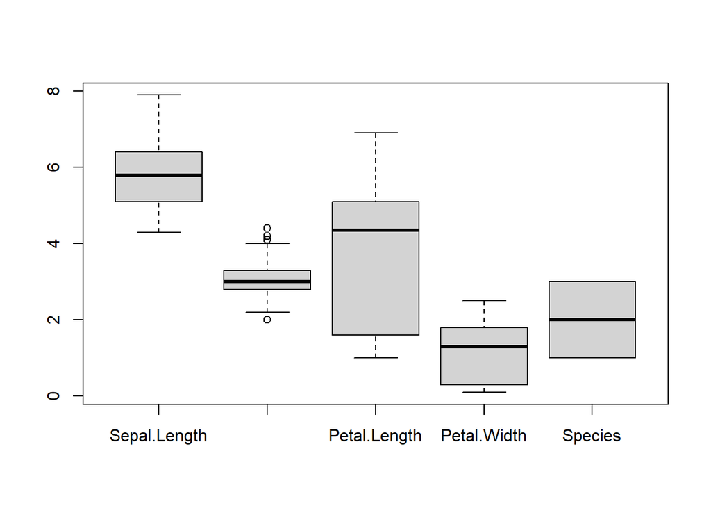

```r
# Boxplot des Iris-Datensatzes, um die Verteilungen der Spalten darzustellen
boxplot(iris)
```

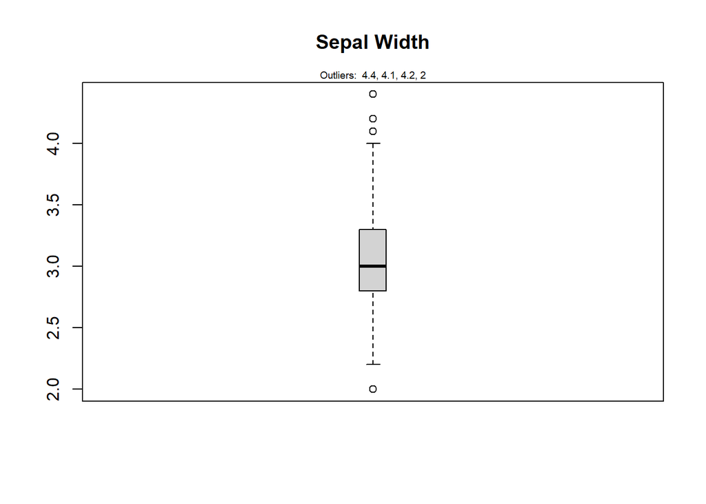

```r
# Ausreisser der Spalte Sepal.Width werden berechnet
# auch andere für den Boxplot relevante Werte können bestimmt werden (ohne $out)
outlier_values <- boxplot.stats(iris$Sepal.Width)$out

# Boxplot nur von Spalte Sepal.Width mit Abbildungsbeschriftung und schmaler/dünner Box/Darstellung
boxplot(iris$Sepal.Width, main="Sepal Width", boxwex=0.1)

# Werte der Ausreisser werden dem Boxplot hinzugefügt
mtext(paste("Outliers: ", paste(outlier_values, collapse=", ")), cex=0.6)

# Die Outlier werden künstliche auf NA gesetzt, danach sind die Ausreisser "weg"
iris_neu <- iris
iris_neu[iris_neu$Sepal.Width %in% outlier_values, "Sepal.Width"] <- NA

# dplyr Variante
library(tidyverse)
```

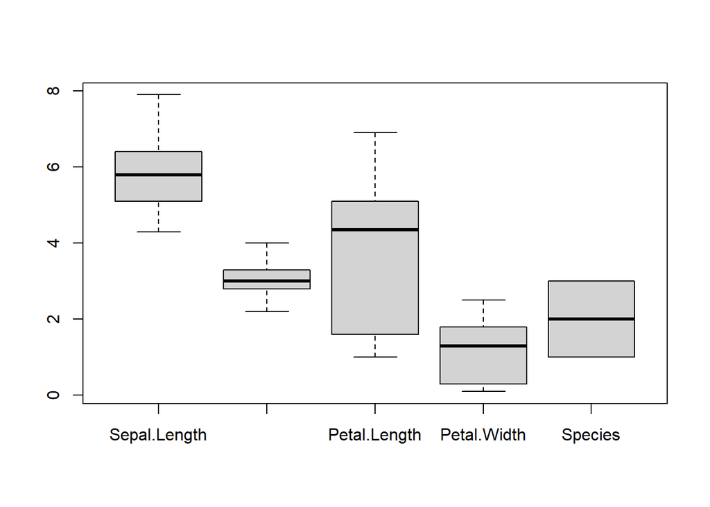

```r
iris_neu <- iris %>%
  mutate(Sepal.Width = replace(Sepal.Width, Sepal.Width %in% outlier_values, NA))
boxplot(iris_neu)
```

## 2.2 Übungsaufgaben

Mit Hilfe des Bike-Datensatzes (http://jgendron.github.io/com.packtpub.intro.r.bi/) werden fehlende Werte/Daten, Ausreisser behandelt, Daten konvertiert und Zeichenketten standardisiert.

```r
# Daten einlesen und Überblick verschaffen
df_bike <- read.csv("02 Data Clean(s)ing/bike.csv", stringsAsFactors = FALSE)
str(df_bike)
```

```
## 'data.frame':    17379 obs. of  13 variables:
##  $ datetime  : chr  "1/1/2011 0:00" "1/1/2011 1:00" "1/1/2011 2:00" "1/1/2011 3:00" ...
##  $ season    : int  1 1 1 1 1 1 1 1 1 1 ...
##  $ holiday   : int  0 0 0 0 0 0 0 0 0 0 ...
##  $ workingday: int  0 0 0 0 0 0 0 0 0 0 ...
##  $ weather   : int  1 1 1 1 1 2 1 1 1 1 ...
##  $ temp      : num  9.84 9.02 9.02 9.84 9.84 ...
##  $ atemp     : num  14.4 13.6 13.6 14.4 14.4 ...
##  $ humidity  : chr  "81" "80" "80" "75" ...
##  $ windspeed : num  0 0 0 0 0 ...
##  $ casual    : int  3 8 5 3 0 0 2 1 1 8 ...
##  $ registered: int  13 32 27 10 1 1 0 2 7 6 ...
##  $ count     : int  16 40 32 13 1 1 2 3 8 14 ...
##  $ sources   : chr  "ad campaign" "www.yahoo.com" "www.google.fi" "AD campaign" ...
```

```r
summary(df_bike)
```

```
##    datetime             season         holiday          workingday
##  Length:17379       Min.   :1.000   Min.   :0.00000   Min.   :0.0000
##  Class :character   1st Qu.:2.000   1st Qu.:0.00000   1st Qu.:0.0000
##  Mode  :character   Median :3.000   Median :0.00000   Median :1.0000
##                     Mean   :2.502   Mean   :0.02877   Mean   :0.6827
##                     3rd Qu.:3.000   3rd Qu.:0.00000   3rd Qu.:1.0000
##                     Max.   :4.000   Max.   :1.00000   Max.   :1.0000
##     weather           temp           atemp         humidity
##  Min.   :1.000   Min.   : 0.82   Min.   : 0.00   Length:17379
##  1st Qu.:1.000   1st Qu.:13.94   1st Qu.:16.66   Class :character
##  Median :1.000   Median :20.50   Median :24.24   Mode  :character
##  Mean   :1.425   Mean   :20.38   Mean   :23.79
##  3rd Qu.:2.000   3rd Qu.:27.06   3rd Qu.:31.06
##  Max.   :4.000   Max.   :41.00   Max.   :50.00
##    windspeed          casual         registered        count
##  Min.   : 0.000   Min.   :  0.00   Min.   :  0.0   Min.   :  1
##  1st Qu.: 7.002   1st Qu.:  4.00   1st Qu.: 36.0   1st Qu.: 42
##  Median :12.998   Median : 16.00   Median :116.0   Median :141
##  Mean   :12.737   Mean   : 34.48   Mean   :152.5   Mean   :187
##  3rd Qu.:16.998   3rd Qu.: 46.00   3rd Qu.:217.0   3rd Qu.:277
##  Max.   :56.997   Max.   :367.00   Max.   :886.0   Max.   :977
##    sources
##  Length:17379
##  Class :character
##  Mode  :character
##
##
##
```

```r
summary(is.na(df_bike))
```

```
##   datetime         season         holiday        workingday
##  Mode :logical   Mode :logical   Mode :logical   Mode :logical
##  FALSE:17379     FALSE:17379     FALSE:17379     FALSE:17379
##
##   weather           temp           atemp          humidity
##  Mode :logical   Mode :logical   Mode :logical   Mode :logical
##  FALSE:17379     FALSE:17379     FALSE:17379     FALSE:17379
##
##  windspeed         casual        registered        count
##  Mode :logical   Mode :logical   Mode :logical   Mode :logical
##  FALSE:17379     FALSE:17379     FALSE:17379     FALSE:17379
##
##   sources
##  Mode :logical
##  FALSE:16825
##  TRUE :554
```

```r
# Fehlerhafte Daten in Spalte humidity entfernen
table(df_bike$humidity)
```

```
##
##   0  10 100  12  13  14  15  16  17  18  19  20  21  22  23  24  25  26  27  28
##  22   1 270   1   1   2   4  10  10  10  16  17  26  27  46  56  59  78  71  97
##  29  30  31  32  33  34  35  36  37  38  39  40  41  42  43  44  45  46  47  48
## 106 113 118  99 162 133 163 187 224 186 209 224 290 235 270 244 248 316 247 240
##  49  50  51  52  53  54  55  56  57  58  59  60  61  62  63  64  65  66  67  68
## 327 266 262 312 267 287 352 310 231 258 272 267 335 325 163 219 387 388 161 172
##  69  70  71  72  73  74  75  76  77  78  79   8  80  81  82  83  84  85  86  87
## 359 430 193 191 317 341 222 219 336 327 238   1 107 275 299 630 124   5  76 488
##  88  89  90  91  92  93  94  96  97 x61
## 657 239   7   1   2 331 560   3   1   1
```

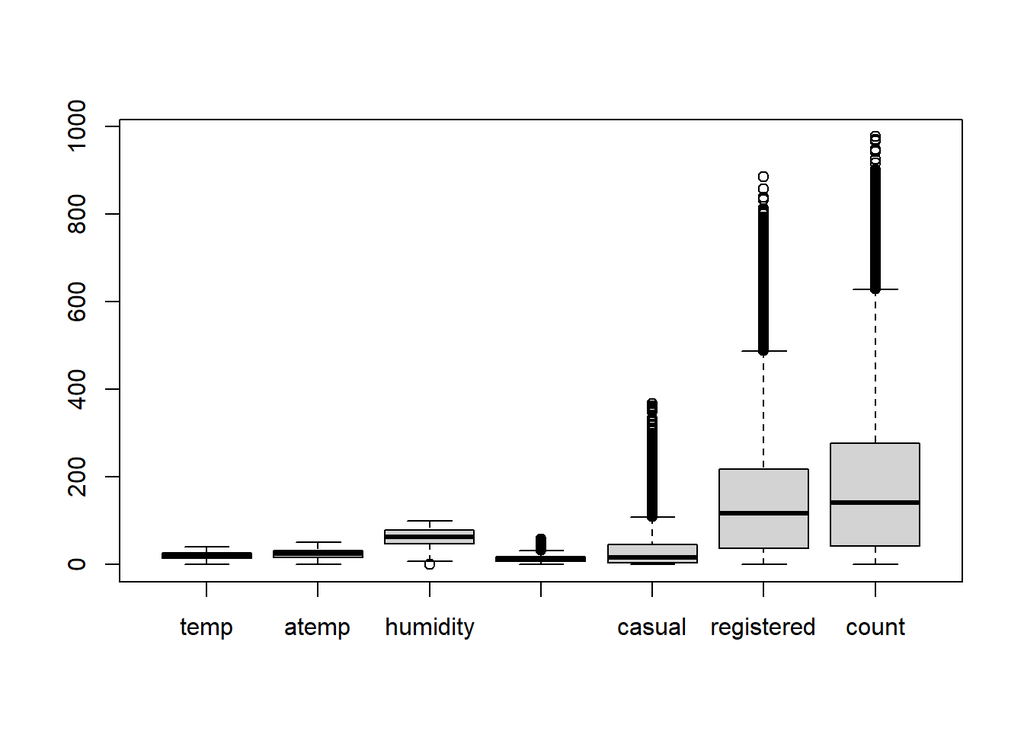

```r
df_bike$humidity <- gsub("[a-z A-Z]","",df_bike$humidity)
df_bike$humidity <- as.numeric(df_bike$humidity)

# Ausreisser zeigen und am Beispiel Windspeed entfernen
boxplot(df_bike[,6:12])
```

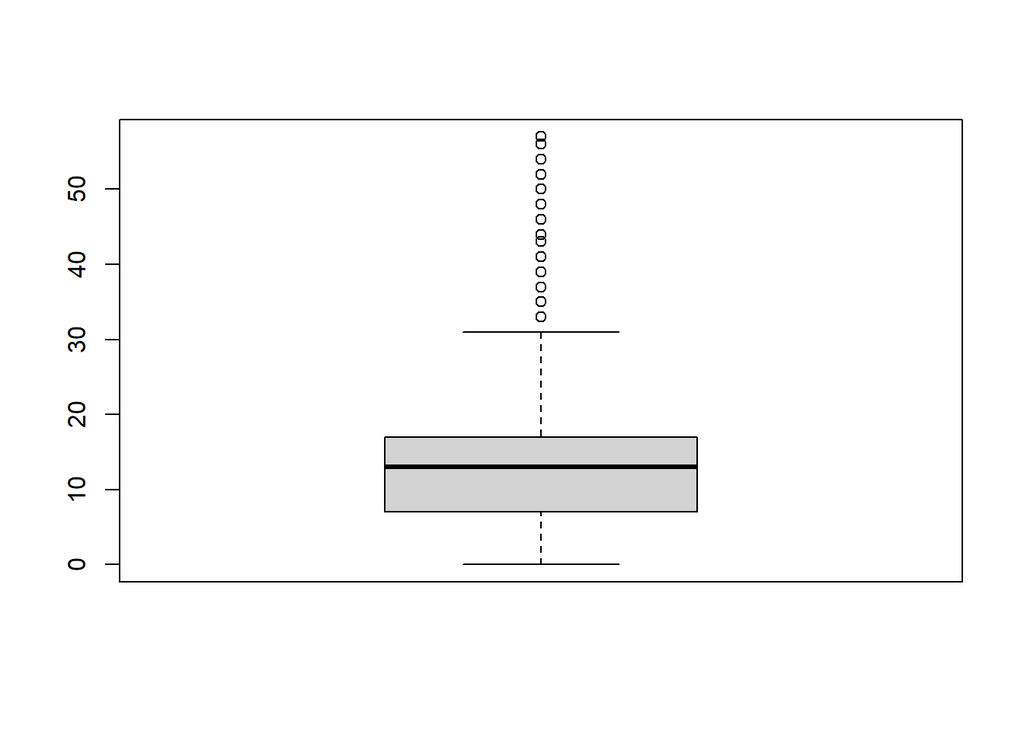

```r
boxplot(df_bike$windspeed)
```

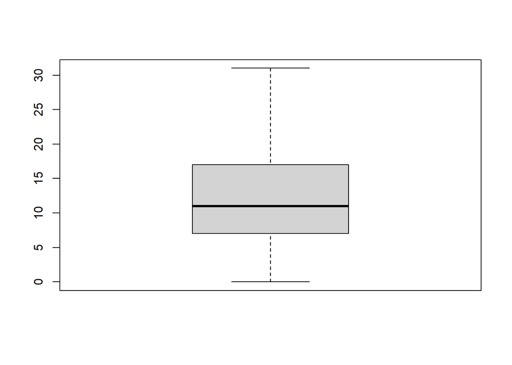

```r
outlier_values <- boxplot.stats(df_bike$windspeed)$out
df_bike[df_bike$windspeed %in% outlier_values, "windspeed"] <- NA
boxplot(df_bike$windspeed)
```

```r
# Datentypkonvertierung (hier Datum)
# library("lubridate")
df_bike$datetime <- mdy_hm(df_bike$datetime)
# df_bike$datetime <- parse_date_time(x = df_bike$datetime, orders = "%m/%d/%Y %H:%M")
# df_bike$datetime <- strptime(x = df_bike$datetime, format = "%m/%d/%Y %H:%M")

# Zeichenketten standardisieren
unique(df_bike$sources)
```

```
##  [1] "ad campaign"      "www.yahoo.com"    "www.google.fi"    "AD campaign"
##  [5] "Twitter"          "www.bing.com"     "www.google.co.uk" "facebook page"
##  [9] "Ad Campaign"      "Twitter    "      NA                 "www.google.com"
## [13] "direct"           "blog"
```

```r
df_bike$sources <- trimws(tolower(df_bike$sources))
df_bike[is.na(df_bike$sources), c("sources")] <- "unknown"
unique(df_bike$sources)
```

```
##  [1] "ad campaign"      "www.yahoo.com"    "www.google.fi"    "twitter"
##  [5] "www.bing.com"     "www.google.co.uk" "facebook page"    "unknown"
##  [9] "www.google.com"   "direct"           "blog"
```

```r
df_bike$holiday <- factor(df_bike$holiday, levels = c(0, 1), labels = c("yes","no"))
df_bike$workingday <- factor(df_bike$workingday, levels = c(0, 1), labels = c("yes","no"))
df_bike$season <- factor(df_bike$season, levels = 1:4, labels = c("spring","summer","autumn","winter"), ordered = TRUE)
df_bike$weather <- factor(df_bike$weather, levels = 1:4, labels = c("clear","mist + cloudy","light rain/snow","heavy rain"), ordered = TRUE)
```

# 3 Feature Engineering

## 3.1 Hausaufgaben

### 3.1.1 One-Hot-Coding

Beim One-Hot-Coding werden kategorielle Attribute (Faktoren) in so viele neue Spalten aufgeteilt wie es Kategorien (N) gibt. Die Ausprägungen der neuen Spalten sind 0 und 1. Bei der Dummy-Codierung wird eine Spalte weggelassen, denn wenn alle andere Spalten 0 sind, hat diese Dummy-Spalte die Ausprägung 1.

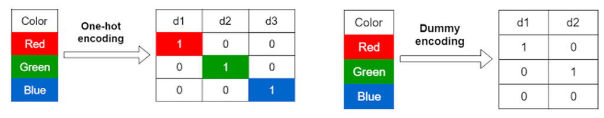

One-Hot-Coding und Dummy-Coding

$\\$

In R gibt es mehrere Möglichkeiten für One-Hot-Coding. Man kann die Libraries “Matrix” oder “fastDummies” nutzen oder manuell umcodieren. Die umcodierte Variable (hier Season) muss jedoch zwingend ein Factor sein!

```r
library(Matrix)
df_one_hot_matrix <- df_bike %>%
  select(datetime, season)
df_one_hot_matrix <- sparse.model.matrix(~.-1, df_one_hot_matrix) # -1 enttfernt Intercept aus Matrix-Objekt
head(df_one_hot_matrix)
```

```
## 6 x 5 sparse Matrix of class "dgCMatrix"
##     datetime seasonspring seasonsummer seasonautumn seasonwinter
## 1 1293840000            1            .            .            .
## 2 1293843600            1            .            .            .
## 3 1293847200            1            .            .            .
## 4 1293850800            1            .            .            .
## 5 1293854400            1            .            .            .
## 6 1293858000            1            .            .            .
```

```r
library(fastDummies)
df_fast_dummies <- df_bike
df_fast_dummies <- dummy_cols(df_fast_dummies, c("season"), remove_selected_columns = TRUE)
str(df_fast_dummies)
```

```
## 'data.frame':    17379 obs. of  16 variables:
##  $ datetime     : POSIXct, format: "2011-01-01 00:00:00" "2011-01-01 01:00:00" ...
##  $ holiday      : Factor w/ 2 levels "yes","no": 1 1 1 1 1 1 1 1 1 1 ...
##  $ workingday   : Factor w/ 2 levels "yes","no": 1 1 1 1 1 1 1 1 1 1 ...
##  $ weather      : Ord.factor w/ 4 levels "clear"<"mist + cloudy"<..: 1 1 1 1 1 2 1 1 1 1 ...
##  $ temp         : num  9.84 9.02 9.02 9.84 9.84 ...
##  $ atemp        : num  14.4 13.6 13.6 14.4 14.4 ...
##  $ humidity     : num  81 80 80 75 75 75 80 86 75 76 ...
##  $ windspeed    : num  0 0 0 0 0 ...
##  $ casual       : int  3 8 5 3 0 0 2 1 1 8 ...
##  $ registered   : int  13 32 27 10 1 1 0 2 7 6 ...
##  $ count        : int  16 40 32 13 1 1 2 3 8 14 ...
##  $ sources      : chr  "ad campaign" "www.yahoo.com" "www.google.fi" "ad campaign" ...
##  $ season_spring: int  1 1 1 1 1 1 1 1 1 1 ...
##  $ season_summer: int  0 0 0 0 0 0 0 0 0 0 ...
##  $ season_autumn: int  0 0 0 0 0 0 0 0 0 0 ...
##  $ season_winter: int  0 0 0 0 0 0 0 0 0 0 ...
```

```r
# manuelles umcodieren z.B. mit dplyr und ifelse
df_manuell <- df_bike %>%
  mutate(spring = ifelse(season == 1, 1, 0),
         summer = ifelse(season == 2, 1, 0),
         fall = ifelse(season == 3, 1, 0),
         winter = ifelse(season == 4, 1, 0))
```

One-hot-Coding muss bei der normalen linearen Regression (LM) nicht zwingend gemacht werden, wenn die Spalte ein Faktor ist. Bei anderen Modellen wird evtl. One-hot-Coding/Dummy benötigt. Das kommt auf das Modell drauf an.

### 3.1.2 Kontraste

Eine kategorielle Variabel wird umcodiert mit One-Hot-Coding. Kontraste vergleichen dann die Referenzwerte (Mittelwerte) der Gruppen miteinander. Es wird beispielsweise das durchschnittliche Gewicht einer Gruppe mit den durchschnittlichen Gewichten der anderen Gruppen verglichen. Das nächsten Level vergleicht jeweils zum vorangegangenen Level. Kontraste dienen dazu, welche Vergleiche angestellt werden sollen.

Im Quiz gabe es Rechenbeispiele dazu. In den Standardeinstellungen von linearen Modellen in R sind die Kontraste “NULL”, die gemäss R-Hilfe eine optionale Liste darstellen.

```r
lm(formula, data, subset, weights, na.action,
   method = "qr", model = TRUE, x = FALSE, y = FALSE, qr = TRUE,
   singular.ok = TRUE, contrasts = NULL, offset, ...)
```

Eine andere Kontrast-Methode ist Helmert, wobei f hier den Spaltennamen meint.

```r
contrasts = list(f = "contr.helmert")
```

Ein konkretes Beispiel mit dem Iris-Datensatz macht das Thema hoffentlich besser greifbar. Zunächst zeigen wir die Daten grafisch und berechnen die exakten Mittelwerte für Sepal.Length. Diese beiden Schritte dienen nur dem Verständnis und der Nachvollziehbarkeit, sind aber eigentlich egal.

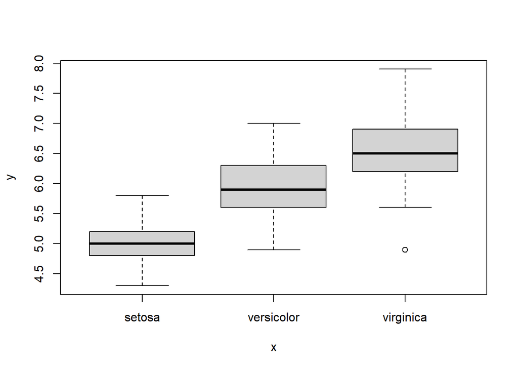

```r
plot(iris$Species, iris$Sepal.Length)
```

```r
tapply(iris$Sepal.Length, iris$Species, mean)
```

```
##     setosa versicolor  virginica
##      5.006      5.936      6.588
```

Jetzt werden zwei Regeresisonen ausgeführt. Die normale LM zeigt in den Schätzern die oben berechneten Mittelwerte je Spezien an (muss kumuliert werden).

```r
summary(lm(Sepal.Length ~ Species, iris))
```

```
##
## Call:
## lm(formula = Sepal.Length ~ Species, data = iris)
##
## Residuals:
##     Min      1Q  Median      3Q     Max
## -1.6880 -0.3285 -0.0060  0.3120  1.3120
##
## Coefficients:
##                   Estimate Std. Error t value Pr(>|t|)
## (Intercept)         5.0060     0.0728  68.762  < 2e-16 ***
## Speciesversicolor   0.9300     0.1030   9.033 8.77e-16 ***
## Speciesvirginica    1.5820     0.1030  15.366  < 2e-16 ***
## ---
## Signif. codes:  0 '***' 0.001 '**' 0.01 '*' 0.05 '.' 0.1 ' ' 1
##
## Residual standard error: 0.5148 on 147 degrees of freedom
## Multiple R-squared:  0.6187, Adjusted R-squared:  0.6135
## F-statistic: 119.3 on 2 and 147 DF,  p-value: < 2.2e-16
```

```r
summary(lm(Sepal.Length ~ Species, iris, contrasts = list(Species = "contr.helmert")))
```

```
##
## Call:
## lm(formula = Sepal.Length ~ Species, data = iris, contrasts = list(Species = "contr.helmert"))
##
## Residuals:
##     Min      1Q  Median      3Q     Max
## -1.6880 -0.3285 -0.0060  0.3120  1.3120
##
## Coefficients:
##             Estimate Std. Error t value Pr(>|t|)
## (Intercept)  5.84333    0.04203 139.020  < 2e-16 ***
## Species1     0.46500    0.05148   9.033 8.77e-16 ***
## Species2     0.37233    0.02972  12.527  < 2e-16 ***
## ---
## Signif. codes:  0 '***' 0.001 '**' 0.01 '*' 0.05 '.' 0.1 ' ' 1
##
## Residual standard error: 0.5148 on 147 degrees of freedom
## Multiple R-squared:  0.6187, Adjusted R-squared:  0.6135
## F-statistic: 119.3 on 2 and 147 DF,  p-value: < 2.2e-16
```

Das lineare Modell mit Helmert-Kontrast kann alternativ auch wie folgt geschrieben werden. Erst wird eine Kopie von iris erstellt und dort für die Spezies die Helmert-Kontraste eingefügt. Danach erfolgt die Regression mit “impliziten” Kotrasten über diesen Datensatz inkl. definierten Kontrasten. Das ist am Ende aber (glaueb ich) das gleiche.

```r
iris_contrasts <- iris
contrasts(iris_contrasts$Species) <- contr.helmert(3)
summary(lm(Sepal.Length ~ Species, iris_contrasts))
```

Bei der Regression mit Kontrasten werden nun die Mittelwerte geschätzt statt die übliche lineare Gleichung. Der Schätzer des Intercepts ist einfach der Mittelwert aller Datenpunkte. Der erste Kontrastschätzer ist Mittel von sich selbst minus Mittelwert von sich slbst und nächstem Gruppenmittelwert (von der t-Apply-Funktion oben). Der nächster Kontrastschätzer ist wieder der eigener Mittelwert minus Mittel des eigenen Mittelwerts und nächster Gruppenmittelwerte.

```r
# Intercept
mean(iris$Sepal.Length)
```

```
## [1] 5.843333
```

```r
# erste Kontrastschätzer
5.936-(5.006+5.936)/2
```

```
## [1] 0.465
```

```r
# zweiter Kontrastschätzer
(5.006+5.936+6.588)/3-(5.006+5.936)/2
```

```
## [1] 0.3723333
```